# Prévision du prix des logements

2024-12-12

### Objectif du modèle

L’objectif est de construire un modèle de régression qui peut prédire le prix d’une propriété en fonction des caractéristiques fournies.

### Description de la tâche

Cette tâche consiste à prédire le prix des propriétés immobilières en fonction de diverses caractéristiques qui influencent la valeur d’une propriété. L’ensemble de données contient plusieurs attributs des propriétés immobilières tels que la superficie, le nombre de chambres, de salles de bains, d’étages, l’année de construction de la propriété, si la propriété dispose d’un jardin ou d’une piscine, la taille du garage, le score d’emplacement et la distance du centre-ville.

### Analyse des données

#### Lien vers la Base de données

[Cliquez ici: Prévision du prix des logements](https://www.kaggle.com/datasets/denkuznetz/housing-prices-regression)

### Variable dépendabte

Prix: La variable cible qui représente le prix de la propriété. C’est la valeur que nous visons à prédire.

### Variables explivatives

Superficie_propriété: La superficie de la propriété en mètres carrés.  
Nombre_Chambres: Le nombre de chambres dans la propriété.  
Nombre_Salles_bain: Le nombre de salles de bains dans la propriété.  
Nombre_Étages: Le nombre d’étages dans la propriété.  
Possede_Jardin : Indique si la propriété a un jardin (1 pour oui, 0 pour non).  
Possede_Piscine: Indique si la propriété a un pool (1 pour oui, 0 pour non).  
Garage_Taille: La taille du garage en mètres carrés. Score_Qualité_quartier: Un score de 0 à 10 indiquant la qualité du quartier (des scores plus élevés indiquent de meilleurs quartiers).  
Distance_Centre_ville: La distance entre la propriété et le centre-ville en kilomètres.

### Affichage des doublons et des valeurs manquantes

```r
prix<-prix%>% filter(!if_any(everything(), is.na))
doublons_prix<-prix[duplicated(prix), ]
print(doublons_prix)
```

```
## # A tibble: 0 × 12
## # ℹ 12 variables: ID <dbl>, Superficie_propriété <chr>, Nombre_Chambres <dbl>,
## #   Nombre_Salles_bain <dbl>, Nombre_Étages <dbl>, Année_Construction <dbl>,
## #   Possede_Jardin <dbl>, Possede_Piscine <dbl>, Garage_Taille  m <dbl>,
## #   Score_Qualité_quartier <chr>, Distance_Centre_ville <chr>, Prix <chr>
```

Interprétation : pas de doublons dans la base de donnée Comme nous n’avons pas de valeurs manquantes et que les variables catégoriques (présence de jardin et de piscine) sont déjà codées en binaire, les données sont prêtes pour la modélisation.

#### Vue d’ensemble de la base de donnée

```r
describe(prix)
```

```
##                         vars   n    mean     sd median trimmed    mad  min  max
## ID                         1 500  250.50 144.48  250.5  250.50 185.32    1  500
## Superficie_propriété*      2 500  250.50 144.48  250.5  250.50 185.32    1  500
## Nombre_Chambres            3 500    2.96   1.44    3.0    2.95   1.48    1    5
## Nombre_Salles_bain         4 500    1.98   0.82    2.0    1.97   1.48    1    3
## Nombre_Étages              5 500    1.96   0.80    2.0    1.96   1.48    1    3
## Année_Construction         6 500 1957.60  35.49 1959.0 1957.22  45.96 1900 2022
## Possede_Jardin             7 500    0.54   0.50    1.0    0.54   0.00    0    1
## Possede_Piscine            8 500    0.49   0.50    0.0    0.49   0.00    0    1
## Garage_Taille  m           9 500   30.17  11.58   30.0   30.35  14.83   10   49
## Score_Qualité_quartier*   10 500  250.50 144.48  250.5  250.50 185.32    1  500
## Distance_Centre_ville*    11 500  250.50 144.48  250.5  250.50 185.32    1  500
## Prix*                     12 500  250.50 144.48  250.5  250.50 185.32    1  500
##                         range  skew kurtosis   se
## ID                        499  0.00    -1.21 6.46
## Superficie_propriété*     499  0.00    -1.21 6.46
## Nombre_Chambres             4  0.06    -1.33 0.06
## Nombre_Salles_bain          2  0.04    -1.52 0.04
## Nombre_Étages               2  0.06    -1.45 0.04
## Année_Construction        122  0.06    -1.25 1.59
## Possede_Jardin              1 -0.14    -1.98 0.02
## Possede_Piscine             1  0.03    -2.00 0.02
## Garage_Taille  m           39 -0.07    -1.22 0.52
## Score_Qualité_quartier*   499  0.00    -1.21 6.46
## Distance_Centre_ville*    499  0.00    -1.21 6.46
## Prix*                     499  0.00    -1.21 6.46
```

### Distribution des observations et repérages des points aberrants : Boites à moustaches

[figure not shown]

```r
par(mfrow=c(4,3),cex=0.1)

{

boxplot(prix$Superficie_propriété,main="Superficie de la propriété en mètres carrés",col="blue" )
boxplot(prix$Nombre_Chambres,main="Nombre de chambres dans la propriété",col="blue")
boxplot(prix$Nombre_Salles_bain,main="Nombre de salles de bains dans la propriété",col="blue")
boxplot(prix$Nombre_Étages,main="Nombre d'étages dans la propriété",col="blue")
boxplot(prix$Possede_Jardin,main="Indique si la propriété a un jardin",col="blue")
boxplot(prix$Possede_Piscine,main="Indique si la propriété a un pool",col="blue")
boxplot(prix$Garage_Taille,main=" Taille du garage en mètres carrés",col="blue")
boxplot(prix$Score_Qualité_quartier,main="Score de la qualité du quartier ",col="blue")
boxplot(prix$Distance_Centre_ville,main="Distance entre la propriété et le centre-ville en kilomètres",col="blue")
boxplot(prix$Prix,main="Prix de la propriété",col="blue")
}
```

Interprétation: Il semble qu’il n’y ait pas de points clairement marqués en dehors des moustaches, donc il n’y a pas de valeurs aberantes visibles dans ces diagrammes qui peuvent créer d’eventuelle probleme de non constance de la variance des residus et de (ou ils sont très rares).Certaines variables semblent binaires ou catégorielles, tandis que d’autres présentent des valeurs continues avec une plus grande variabilité.

### Estimation du modèle par la methode des Moindres carrées ordinnaires (MCO)

```r
prix_reg<-lm(Prix~Superficie_propriété+Nombre_Chambres+Nombre_Salles_bain+Nombre_Étages+Possede_Jardin+Possede_Piscine+Garage_Taille+Score_Qualité_quartier+Distance_Centre_ville, data=prix)
summary(prix_reg)
```

```
##
## Call:
## lm(formula = Prix ~ Superficie_propriété + Nombre_Chambres +
##     Nombre_Salles_bain + Nombre_Étages + Possede_Jardin + Possede_Piscine +
##     Garage_Taille + Score_Qualité_quartier + Distance_Centre_ville,
##     data = prix)
##
## Residuals:
##     Min      1Q  Median      3Q     Max
## -122936  -48291    -666   44105  127802
##
## Coefficients:
##                        Estimate Std. Error t value Pr(>|t|)
## (Intercept)            79650.92   16551.86   4.812 1.99e-06 ***
## Superficie_propriété     977.85      34.72  28.167  < 2e-16 ***
## Nombre_Chambres        51762.19    1792.81  28.872  < 2e-16 ***
## Nombre_Salles_bain     29153.63    3154.28   9.243  < 2e-16 ***
## Nombre_Étages          24258.41    3224.04   7.524 2.56e-13 ***
## Possede_Jardin         29672.69    5179.09   5.729 1.76e-08 ***
## Possede_Piscine        40646.57    5216.17   7.792 3.96e-14 ***
## Garage_Taille           1114.41     223.99   4.975 9.03e-07 ***
## Score_Qualité_quartier  4831.40     906.78   5.328 1.52e-07 ***
## Distance_Centre_ville  -2011.24     468.59  -4.292 2.13e-05 ***
## ---
## Signif. codes:  0 '***' 0.001 '**' 0.01 '*' 0.05 '.' 0.1 ' ' 1
##
## Residual standard error: 57370 on 490 degrees of freedom
## Multiple R-squared:  0.7838, Adjusted R-squared:  0.7798
## F-statistic: 197.4 on 9 and 490 DF,  p-value: < 2.2e-16
```

### Interprétation des résultats :

Intercepter (constante) : L’intercept est de 79 650,92, ce qui signifie que si toutes les caracteristiques des logements étaient égales à zéro, le prix de la propriété serait estimé à 79 650,92.

Signification des variables : Dans notre modèle, toutes les variables ont des p-values inférieures à 0,05 (elles sont toutes significatives à un niveau de 1 %), ce qui indique que chaque variable incluse dans notre modele a un effet statistiquement significatif sur le prix de la propriété.

Statistiques globales du modèle

Erreur standard résiduelle : 57 370, Cela donne une mesure de la dispersion des erreurs résiduelles autour de la droite de régression. Plus l’erreur est petite, plus les prédictions du prix de logements sont précises.

R-carré multiple (R² = 0,7838) : Cela indique que 78,38 % de la variation du prix des propriétés est expliquée par les variables explicatives dans notre modèle. Le R² de 0.7838 est relativement élevé, ce qui suggère que le modèle explique une grande partie de la variation du prix des propriétés.

R-carré ajusté (R² ajusté = 0,7798) : Cette mesure est utilisée pour ajuster le R² en fonction du nombre de variables dans le modèle. L’ajustement est important pour éviter la surévaluation de la qualité du modèle lorsque trop de variables sont utilisées. Dans notre cas, l’ajustement est assez similaire au R² multiple, ce qui est positif.

F-statistique ou Test de significativité conjointe (F = 197,4) : Cette statistique teste l’hypothèse nulle selon laquelle tous les coefficients de régression sont égaux à zéro (c’est-à-dire qu’aucune variable n’a d’effet). Ici, la p-value associée à cette statistique est extrêmement faible (< 2.2e-16), ce qui signifie que le modèle est globalement significatif et que les variables sont collectivement utiles pour expliquer la variation du prix des propriétés.

### Test de significativité individuel :

Verifier si les coefficients sont significativement différent de 0 au seuil de 5%

### Extraire les p-values des coefficients

```r
p_values <- summary(prix_reg)$coefficients[, 4]
print(p_values)
```

```
##            (Intercept)   Superficie_propriété        Nombre_Chambres
##           1.990948e-06          1.626948e-104          8.398862e-108
##     Nombre_Salles_bain          Nombre_Étages         Possede_Jardin
##           7.356364e-19           2.558177e-13           1.762386e-08
##        Possede_Piscine          Garage_Taille Score_Qualité_quartier
##           3.964491e-14           9.032758e-07           1.516371e-07
##  Distance_Centre_ville
##           2.133939e-05
```

Vérifier les variables sont significatives au seuil de 5%

```r
significatif_5pct <- p_values < 0.05
print(significatif_5pct)
```

```
##            (Intercept)   Superficie_propriété        Nombre_Chambres
##                   TRUE                   TRUE                   TRUE
##     Nombre_Salles_bain          Nombre_Étages         Possede_Jardin
##                   TRUE                   TRUE                   TRUE
##        Possede_Piscine          Garage_Taille Score_Qualité_quartier
##                   TRUE                   TRUE                   TRUE
##  Distance_Centre_ville
##                   TRUE
```

Interpreétation : Chaque variable dans notre modèle est significative pour expliquer le prix des propriétés, ce qui rend Notre modèle robuste et globalement significatif.

### Calcul de la variance

```r
anova<-aov(prix_reg)
summary(anova)
```

```
##                         Df    Sum Sq   Mean Sq F value   Pr(>F)
## Superficie_propriété     1 2.328e+12 2.328e+12  707.26  < 2e-16 ***
## Nombre_Chambres          1 2.620e+12 2.620e+12  795.95  < 2e-16 ***
## Nombre_Salles_bain       1 2.741e+11 2.741e+11   83.28  < 2e-16 ***
## Nombre_Étages            1 1.605e+11 1.605e+11   48.75 9.50e-12 ***
## Possede_Jardin           1 7.736e+10 7.736e+10   23.50 1.68e-06 ***
## Possede_Piscine          1 1.594e+11 1.594e+11   48.44 1.10e-11 ***
## Garage_Taille            1 8.352e+10 8.352e+10   25.37 6.65e-07 ***
## Score_Qualité_quartier   1 8.423e+10 8.423e+10   25.59 5.98e-07 ***
## Distance_Centre_ville    1 6.064e+10 6.064e+10   18.42 2.13e-05 ***
## Residuals              490 1.613e+12 3.292e+09
## ---
## Signif. codes:  0 '***' 0.001 '**' 0.01 '*' 0.05 '.' 0.1 ' ' 1
```

```r
aov(prix_reg)
```

```
## Call:
##    aov(formula = prix_reg)
##
## Terms:
##                 Superficie_propriété Nombre_Chambres Nombre_Salles_bain
## Sum of Squares          2.327941e+12    2.619882e+12       2.741257e+11
## Deg. of Freedom                    1               1                  1
##                 Nombre_Étages Possede_Jardin Possede_Piscine Garage_Taille
## Sum of Squares   1.604637e+11   7.736184e+10    1.594478e+11  8.351587e+10
## Deg. of Freedom             1              1               1             1
##                 Score_Qualité_quartier Distance_Centre_ville    Residuals
## Sum of Squares            8.422576e+10          6.063652e+10 1.612840e+12
## Deg. of Freedom                      1                     1          490
##
## Residual standard error: 57371.68
## Estimated effects may be unbalanced
```

### Calcul et affichage des residus

```r
prix$residus<-residuals(prix_reg)
summary(prix$residus)
```

```
##    Min. 1st Qu.  Median    Mean 3rd Qu.    Max.
## -122936  -48291    -666       0   44105  127802
```

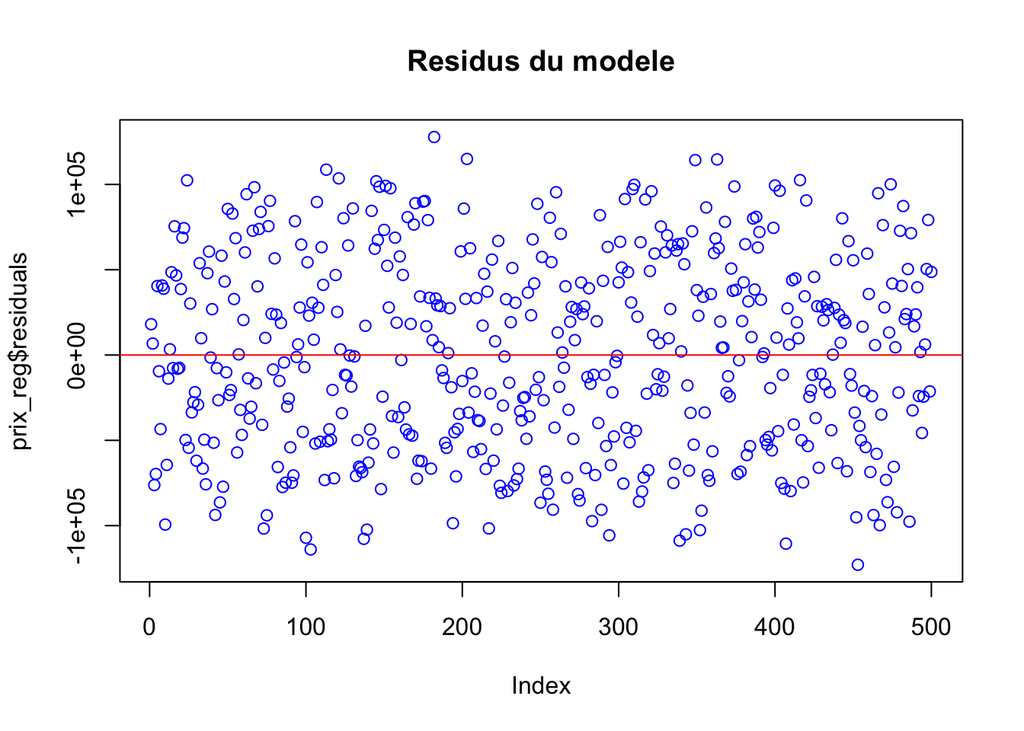

```r
par(mfrow=c(1,1))
plot(prix_reg$residuals,main = "Residus du modele",col="blue")
abline(h=0,col="red")
```

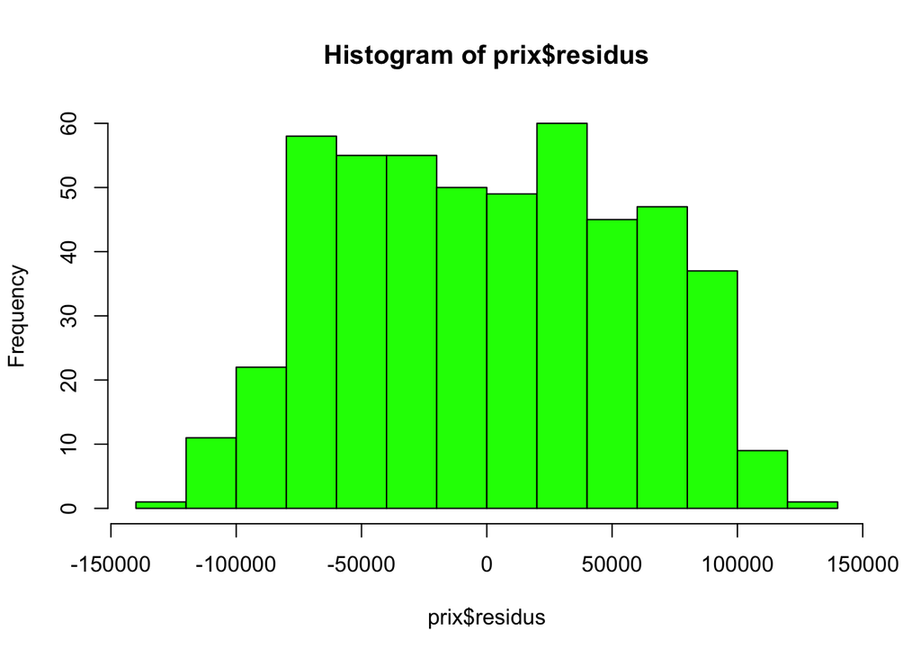

```r
hist(prix$residus,col = "green")
```

Interprétation: Ce graphique suggère que le modèle de régression est globalement bien ajusté, avec une distribution des résidus autour de zéro qui semble aléatoire, il semble egalement que les résidus soient dispersés de manière relativement constante, ce qui est un bon signe. Cependant, certaines observations éloignées de la ligne zéro peuvent indiquer des points aberrants Ou des observations mal ajustées par le modèle, qui mériteraient une étude plus approfondie avec des tests approprié

### Une autre manière d’extraire et de visualiser les résidus

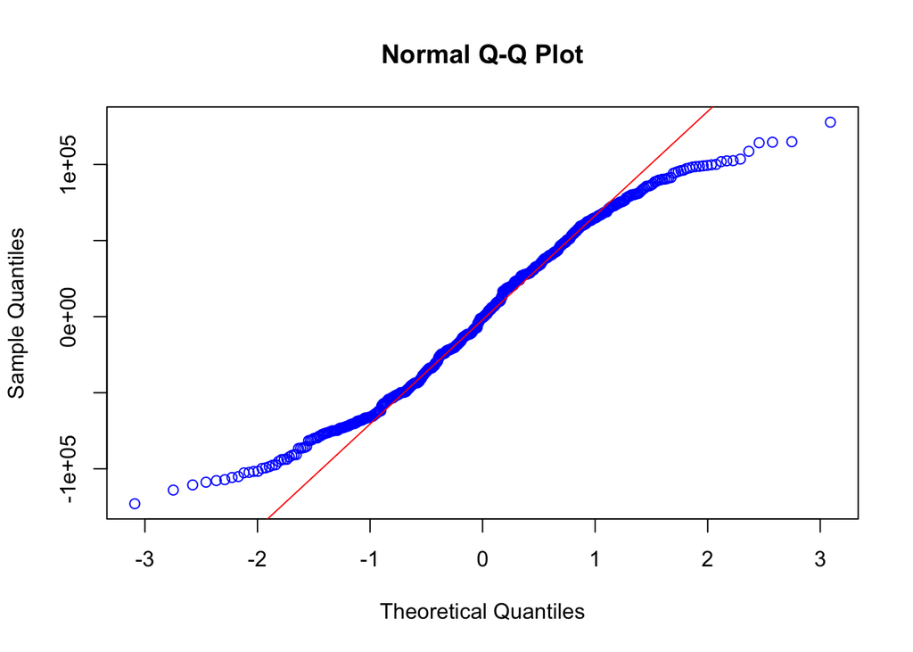

```r
qqnorm(residuals(prix_reg),col="blue")
qqline(residuals(prix_reg),col="red")
```

Interprétation: On peut voir que les points aux extrémités (c’est-à-dire dans les queues de la distribution) s’écartent de manière significative de la ligne rouge. Cela suggère que les résidus ne suivent pas complètement une distribution normale.

Partie centrale : Au centre du graphique, les points sont relativement proches de la ligne rouge, ce qui indique que dans cette région, les résidus sont plus proches d’une distribution normale.

Hétéroskédasticité ou non-normalité des résidus : L’écart des points par rapport à la ligne rouge, surtout aux extrémités, suggère que les résidus pourraient ne pas être normalement distribués. Cela peut indiquer un problème de non-normalité des erreurs ou la présence d’une hétéroskédasticité. il serait donc intéressant de vérifier la présence d’hétéroskédasticité à l’aide de tests comme le test de Breusch-Pagan ou White.

### H2 Exogénéité des variables explicatives

Verifier si les variables sont corrélées entre elles

```r
data_bis = prix[, c("Superficie_propriété", "Nombre_Chambres", "Nombre_Salles_bain","Nombre_Étages",
                    "Possede_Jardin", "Possede_Piscine", "Garage_Taille", "Score_Qualité_quartier",
                    "Distance_Centre_ville"  )]
corr.matrix <- cor(data_bis)
corr.matrix
```

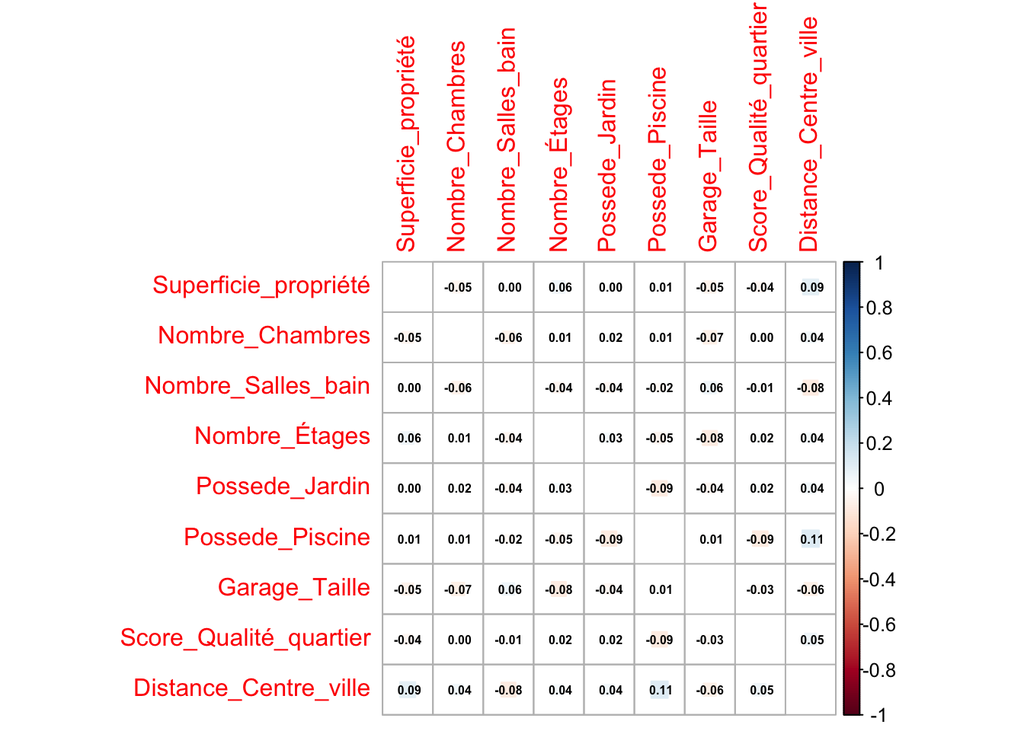

```r
corrplot(corr.matrix, method = 'square', diag = F, addCoef.col ='black', number.cex = 0.5)
```

Cela suggère que nos variables sont relativement indépendantes, ce qui peut indiquer qu’il y a peu de colinéarité dans nos données, ce qui est généralement favorable pour notre modèle de régression

### Calcul VIF : Variance Inflation Factor

Test la corrélation des Variables Explicatitives

```r
vif(lm(Prix~Superficie_propriété+Nombre_Chambres+Nombre_Salles_bain+Nombre_Étages+Possede_Jardin+Possede_Piscine+Garage_Taille+Score_Qualité_quartier+Distance_Centre_ville, data=prix))
```

```
##   Superficie_propriété        Nombre_Chambres     Nombre_Salles_bain
##               1.018787               1.011771               1.014778
##          Nombre_Étages         Possede_Jardin        Possede_Piscine
##               1.014815               1.013363               1.033015
##          Garage_Taille Score_Qualité_quartier  Distance_Centre_ville
##               1.020390               1.014994               1.039530
```

Interprétation des VIF des coefficients: tous les VIF des variables explicatives sont inferieurs à 5, ce qui sugerent qu’on a pas un problème de multicolinéarité en entre les variables

### Test d’endogénéité

Vérifier la corrélation entre les résidus et les variables explicatives

```r
residuals <- residuals(prix_reg)

endo <- vector("numeric", length = ncol(prix))
for (i in 1:ncol(prix)) {
  cor_residuals <- cor(residuals, prix[[i]])
  endo[i] <- cor_residuals
}

print(endo)
```

```
##  [1]  1.272474e-02  1.582699e-17 -1.712242e-16 -1.888635e-16 -1.140965e-16
##  [6]  9.378167e-01 -7.064329e-17 -7.226272e-17 -5.845789e-18  3.020003e-17
## [11] -5.580925e-17  4.649576e-01 -5.845789e-18  1.000000e+00
```

Interprétation: La plupart des variables explicatives sont proches de 0, cela signifie qu’elles ne sont pas corrélés avec les termes d’erreurs. (La valeur 4.649576e-01 est pour la variable dépendante et celle de 9.378167e-01 est pour les années de construction que nous n’avons pas pris en compte dans notre modèle). Il n’y a donc pas d’endogénéité dans notre modèle.

### H3 Homocedastique des residus

verifier si les residus sont homocedastique c’est-à-dire si la variance des residus est constante.

### Test de Breush-Pagan

```r
bptest(prix_reg)
```

```
##
##  studentized Breusch-Pagan test
##
## data:  prix_reg
## BP = 5.9804, df = 9, p-value = 0.7419
```

### Test de white

```r
white_test(prix_reg)
```

```
## White's test results
##
## Null hypothesis: Homoskedasticity of the residuals
## Alternative hypothesis: Heteroskedasticity of the residuals
## Test Statistic: 0.6
## P-value: 0.741013
```

Interprétation test de white : le test statistique (0.6) est une mesure de l’écart entre les résidus observés et ce que l’on attend sous l’hypothèse nulle d’homoscédasticité. Ce chiffre est relativement faible, ce qui suggère que l’écart par rapport à l’hypothèse nulle n’est pas très important.

La p-value de 0.741013 est bien supérieure au seuil de signification habituel de 0.05 (ou même 0.01). Cela signifie qu’il n’y a pas suffisamment de preuves statistiques pour conclure que les résidus sont hétéroscédastiques. En d’autres termes, selon ce test de White, il n’y a pas de preuve de la présence d’hétéroscédasticité dans notre modèle de régression. nous pouvez donc supposer que les résidus sont homoscédastiques (la variance des résidus est constante).

### H4 Absence d’auto-corrélation des résidus

Verifier si les residus sont correlés entre elles

### Test d’auto-corrélation

```r
dw_test <- durbinWatsonTest(prix_reg)
print(dw_test)
```

```
##  lag Autocorrelation D-W Statistic p-value
##    1      0.01406197      1.970201   0.734
##  Alternative hypothesis: rho != 0
```

Petite conclusion: Toutes les hypothèses fondamentales de Gauss-Markov sont respéctées, nous pouvons donc intérpréter nos resultats et predire les prix de notre modèle.

### Discution des résultats du modèle

- Le prix dee base d’un bien immobilier lorsqu’aucune des autres variables n’est présente est de 79,650.92€
- Pour chaque mètre carré supplémentaire de superficie, le prix du bien augmente en moyenne de 977,85 €.
- Pour chaque chambre en plus, le prix augmente en moyenne de 51 762,19 €.
- Une augmentation de la distance au centre-ville d’1km diminue le prix en moyenne de 2 011,24 €.

### Prédiction des prix à partir du modèle

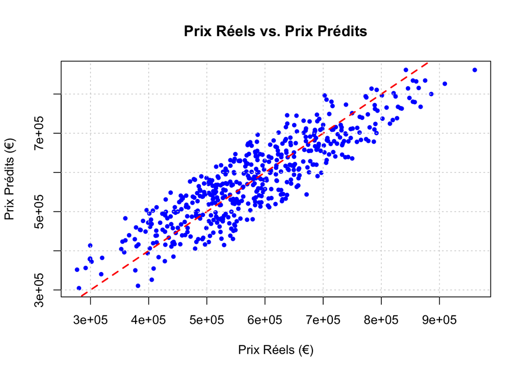

```r
prediction<- predict(prix_reg, newdata = prix)
prix$prediction<- predict(prix_reg, newdata =prix)

plot(prix$Prix, prediction,
     xlab = "Prix Réels (€)",
     ylab = "Prix Prédits (€)",
     main = "Prix Réels vs. Prix Prédits",
     col = "blue", pch = 20)
abline(a = 0, b = 1, col = "red", lwd = 2, lty = 2)
grid()
```

Interprétation: Le graphique «Prix réels vs. prix prédits» montre une forte corrélation entre les prix réels et ceux estimés par le modèle, avec une majorité de points proches de la ligne rouge diagonale, indiquant une bonne précision globale. Les écarts sont majoritairement faibles, bien que certaines observations présentent des sous ou sur-estimations notables.

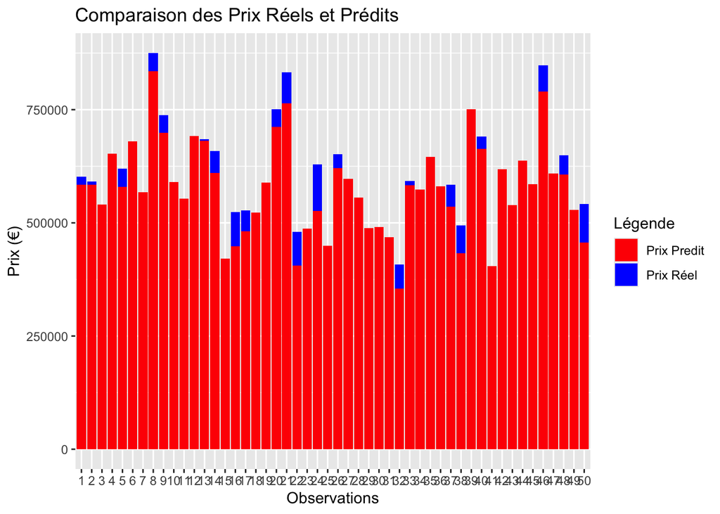

```r
comparaison <- data.frame(
  Observations = 1:50,
  Prix_Réel = prix$Prix[1:50],
  Prix_Predit = prediction[1:50]
)

library(ggplot2)

ggplot(comparaison, aes(x = factor(Observations))) +
  geom_bar(aes(y = Prix_Réel, fill = "Prix Réel"), stat = "identity", position = "dodge") +
  geom_bar(aes(y = Prix_Predit, fill = "Prix Predit"), stat = "identity", position = "dodge") +
  scale_fill_manual(values = c("Prix Réel" = "blue", "Prix Predit" = "red")) +
  labs(
    title = "Comparaison des Prix Réels et Prédits",
    x = "Observations",
    y = "Prix (€)",
    fill = "Légende")
```

Attention: ce graphique a été réalisé avec les 50 premières observations afin que cela reste lisible

### Poursuite de l’analyse avec le modèle Logit

Nous pouvons déterminer si le prix d’une maison est considérer comme “élevé” ou “faible”

### On calcul la médiane pour déterminer si un prix est élevée ou non

```r
mediane_prix <- median(prix$Prix, na.rm = TRUE)
print(mediane_prix)
```

```
## [1] 574724.1
```

Interpretation : Donc le prix est considéré élevé si > 574 724

### Il faut ensuite créer la variable binaire “Prix_élevé” de 1 si > 574724, sinon 0

```r
prix$Prix_élevé <- ifelse(prix$Prix > 574724, 1, 0)
str(prix$Prix_élevé)
```

```
##  num [1:500] 1 1 0 1 1 1 0 1 1 0 ...
```

Nous pouvons désormais estimer notre modèle logit

```r
prix_logit <- glm(Prix_élevé ~ Superficie_propriété + Nombre_Chambres +
                     Nombre_Salles_bain + Nombre_Étages + Possede_Jardin +
                     Possede_Piscine + Garage_Taille + Score_Qualité_quartier+ Distance_Centre_ville,
                   data = prix,
                   family = binomial)
summary(prix_logit)
```

```
##
## Call:
## glm(formula = Prix_élevé ~ Superficie_propriété + Nombre_Chambres +
##     Nombre_Salles_bain + Nombre_Étages + Possede_Jardin + Possede_Piscine +
##     Garage_Taille + Score_Qualité_quartier + Distance_Centre_ville,
##     family = binomial, data = prix)
##
## Coefficients:
##                          Estimate Std. Error z value Pr(>|z|)
## (Intercept)            -14.108809   1.416111  -9.963  < 2e-16 ***
## Superficie_propriété     0.029356   0.002814  10.432  < 2e-16 ***
## Nombre_Chambres          1.357345   0.136949   9.911  < 2e-16 ***
## Nombre_Salles_bain       0.887193   0.178294   4.976 6.49e-07 ***
## Nombre_Étages            0.528979   0.180227   2.935  0.00333 **
## Possede_Jardin           0.877016   0.284337   3.084  0.00204 **
## Possede_Piscine          1.369648   0.296236   4.624 3.77e-06 ***
## Garage_Taille            0.039041   0.012289   3.177  0.00149 **
## Score_Qualité_quartier   0.125702   0.048779   2.577  0.00997 **
## Distance_Centre_ville   -0.067912   0.026047  -2.607  0.00913 **
## ---
## Signif. codes:  0 '***' 0.001 '**' 0.01 '*' 0.05 '.' 0.1 ' ' 1
##
## (Dispersion parameter for binomial family taken to be 1)
##
##     Null deviance: 693.15  on 499  degrees of freedom
## Residual deviance: 344.77  on 490  degrees of freedom
## AIC: 364.77
##
## Number of Fisher Scoring iterations: 6
```

Interpretation : Néanmoins nous ne pouvons pas interpréter les coefficients, seulement leur signe

### Test R²

```r
PR2 = pR2(prix_logit)
```

```
## fitting null model for pseudo-r2
```

```r
print(PR2)
```

```
##          llh      llhNull           G2     McFadden         r2ML         r2CU
## -172.3871089 -346.5735903  348.3729629    0.5025959    0.5017961    0.6690615
```

Interprétation: McFadden R² : 0.5026 → Nous pouvons considérer que le modèle améliore significativement les prédictions par rapport à un modèle sans aucune information

Il faut créer de nouvelles colonnes “proba_prédite”, “classe_prédite”, qui respectivement donne la probabilité de si la maison a un prix elevé ou non, et lui assigne 1 si proba > 0,5, sinon 0

### Prédire les probabilités que la maison soit chère

```r
prix$proba_prédite <- predict(prix_logit, type = "response")
```

### Convertir les probabilités en classes binaires. Les proba deviennent donc 1 ou 0

```r
prix$classe_prédite <- ifelse(prix$proba_prédite > 0.5, 1, 0)
```

### Matrice de confusion permet de montrer combien de prediction sont juste ou pas

```r
Matrice_confusion = table(Actual = prix$Prix_élevé, Predicted = prix$classe_prédite)
print(Matrice_confusion)
```

```
##       Predicted
## Actual   0   1
##      0 213  37
##      1  48 202
```

Interprétation: Ici le modèle à bien estimé 213 prix faible quand ils étaient faibles, mais en a aussi prédit 48 faibles alors qu’ils étaient élevé

### Calcul de la probabilité de trouver si une maison est réellement chère ou non

```r
VP <- 202  # Vrais Positifs
VN <- 213  # Vrais Négatifs
FP <- 37   # Faux Positifs
FN <- 48   # Faux Négatifs

total <- VP + VN + FP + FN

accuracy <- (VP + VN) / total

print(paste("Précision globale (Accuracy) :", round(accuracy * 100, 2), "%"))
```

```
## [1] "Précision globale (Accuracy) : 83 %"
```

### Illustration montrant la relation entre la superficie et la probabilité que le prix soit élevé

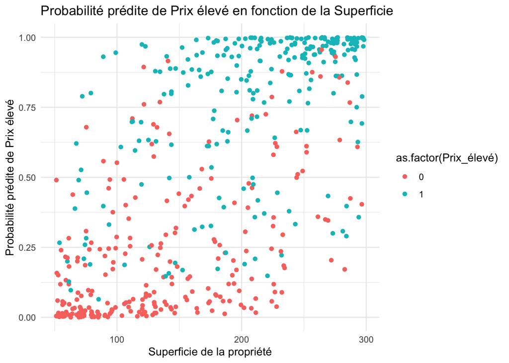

```r
Cor_Prix_Surface = ggplot(prix, aes(x = Superficie_propriété, y = proba_prédite, color = as.factor(Prix_élevé))) +
  geom_point() +
  labs(title = "Probabilité prédite de Prix élevé en fonction de la Superficie",
       x = "Superficie de la propriété",
       y = "Probabilité prédite de Prix élevé") +
  theme_minimal()
print (Cor_Prix_Surface)
```

Tendance générale : Plus la superficie de la propriété augmente, plus la probabilité prédite d’avoir un Prix élevé augmente

### Prédictions pour de nouveaux cas

### Créer un nouveau dataframe avec les caractéristiques la maison

```r
nouvelle_maison <- data.frame(
  Superficie_propriété = 150,
  Nombre_Chambres= 2,
  Nombre_Salles_bain = 1,
 Nombre_Étages = 1,
  Possede_Jardin = 1,
  Possede_Piscine = 1,
  Garage_Taille = 48,
  Score_Qualité_quartier = 8,
  Distance_Centre_ville = 6
)
```

### Prédit la probabilité avec le modèle logit

```r
proba_logit <- predict(prix_logit, newdata = nouvelle_maison, type = "response")
print(proba_logit)
```

```
##         1
## 0.2982194
```

### Affichage en binaire

```r
# Convertir en classe binaire
classe_predite <- ifelse(proba_logit > 0.5, "Prix élevé", "Prix faible")
print(classe_predite)
```

```
##             1
## "Prix faible"
```